# R Notebook

# Resource Hints Performance

# Housekeeping

First we set the working directory

```r
dir = "/home/omar/thesis-replication-package/resource_hints/data_analysis"
```

```r
setwd(dir)
```

Next we import the libraries we need.

```r
library(ggplot2)
library(e1071)
library(dplyr)
library(effsize)
# Import functins we created outselves.
source("util.r")
```

# Getting the data

We load the data and then reshape it a little bit to make it easier to work with.

```r
monsoon_raw_data <- read.csv("../raw_data/Aggregated_Results_Monsoon.csv")
plt_raw_data <- read.csv("../raw_data/http_post_request_payloads.txt")
combined_data = combine_and_reshape_dataframes(monsoon_raw_data, plt_raw_data, "noremovehints")
intact = combined_data[1:200,]
removed = combined_data[201:400,]
print(combined_data)
```

|  | subject | treatment | run | energy_joules | plt |
| --- | --- | --- | --- | --- | --- |
| 1 | axomjobs-in | intact | 1 | 15.585548 | 4193 |
| 81 | axomjobs-in | intact | 2 | 14.181899 | 4462 |
| 161 | axomjobs-in | intact | 3 | 15.876018 | 4124 |
| 241 | axomjobs-in | intact | 4 | 14.414035 | 4185 |
| 321 | axomjobs-in | intact | 5 | 15.464642 | 4258 |
| 3 | beautydea-it | intact | 1 | 13.825483 | 6834 |
| 83 | beautydea-it | intact | 2 | 13.082055 | 6751 |
| 163 | beautydea-it | intact | 3 | 12.104269 | 6334 |
| 243 | beautydea-it | intact | 4 | 13.761875 | 7658 |
| 323 | beautydea-it | intact | 5 | 12.735576 | 6172 |

[output cut: 390 more lines]

```r
print(intact)
```

|  | subject | treatment | run | energy_joules | plt |
| --- | --- | --- | --- | --- | --- |
| 1 | axomjobs-in | intact | 1 | 15.585548 | 4193 |
| 81 | axomjobs-in | intact | 2 | 14.181899 | 4462 |
| 161 | axomjobs-in | intact | 3 | 15.876018 | 4124 |
| 241 | axomjobs-in | intact | 4 | 14.414035 | 4185 |
| 321 | axomjobs-in | intact | 5 | 15.464642 | 4258 |
| 3 | beautydea-it | intact | 1 | 13.825483 | 6834 |
| 83 | beautydea-it | intact | 2 | 13.082055 | 6751 |
| 163 | beautydea-it | intact | 3 | 12.104269 | 6334 |
| 243 | beautydea-it | intact | 4 | 13.761875 | 7658 |
| 323 | beautydea-it | intact | 5 | 12.735576 | 6172 |

[output cut: 190 more lines]

```r
print(removed)
```

|  | subject | treatment | run | energy_joules | plt |
| --- | --- | --- | --- | --- | --- |
| 2 | axomjobs-in | removed | 1 | 13.328838 | 4209 |
| 82 | axomjobs-in | removed | 2 | 15.551003 | 5370 |
| 162 | axomjobs-in | removed | 3 | 16.144409 | 4130 |
| 242 | axomjobs-in | removed | 4 | 13.217263 | 4031 |
| 322 | axomjobs-in | removed | 5 | 13.421656 | 3530 |
| 4 | beautydea-it | removed | 1 | 13.306967 | 6363 |
| 84 | beautydea-it | removed | 2 | 12.652506 | 6222 |
| 164 | beautydea-it | removed | 3 | 13.588833 | 6717 |
| 244 | beautydea-it | removed | 4 | 13.157506 | 6213 |
| 324 | beautydea-it | removed | 5 | 13.590112 | 6669 |

[output cut: 190 more lines]

# Data Exploration

First lets get some summaries of the data..

```r
print("All")
```

```
[1] "All"
```

```r
summary(combined_data$plt)
```

```
   Min. 1st Qu.  Median    Mean 3rd Qu.    Max.
   1523    5032    7381    8450   10437   31124
```

```r
sd(combined_data$plt)
```

```
[1] 4944.214
```

```r
print("Intact")
```

```
[1] "Intact"
```

```r
summary(intact$plt)
```

```
   Min. 1st Qu.  Median    Mean 3rd Qu.    Max.
   1523    5617    7864    8704   10523   29112
```

```r
sd(intact$plt)
```

```
[1] 4966.855
```

```r
print("Removed")
```

```
[1] "Removed"
```

```r
summary(removed$plt)
```

```
   Min. 1st Qu.  Median    Mean 3rd Qu.    Max.
   1564    4802    7090    8195   10178   31124
```

```r
sd(removed$plt)
```

```
[1] 4920.742
```

Then we make a boxplot of the data.

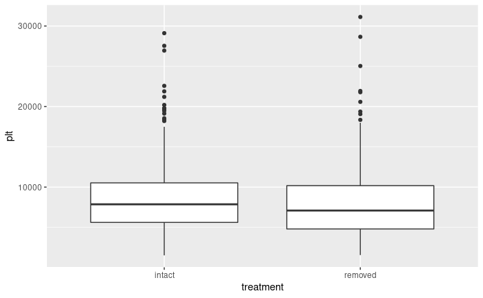

```r
ggplot(combined_data, aes(x=treatment, y=plt)) +
  geom_boxplot()
```

Lets inspect the outliers..

```r
outliers <- boxplot.stats(combined_data$plt)$out
out_ind <- which(combined_data$plt %in% c(outliers))
outliers <- combined_data[out_ind,]
print(outliers)
```

|  | subject | treatment | run | energy_joules | plt |
| --- | --- | --- | --- | --- | --- |
| 15 | dallasnews-com | intact | 1 | 49.97826 | 22568 |
| 95 | dallasnews-com | intact | 2 | 63.57723 | 29112 |
| 175 | dallasnews-com | intact | 3 | 47.58584 | 19459 |
| 255 | dallasnews-com | intact | 4 | 49.17157 | 21887 |
| 335 | dallasnews-com | intact | 5 | 47.77974 | 20199 |
| 277 | jezebel-com | intact | 4 | 37.92969 | 19129 |
| 47 | nationalreview-com | intact | 1 | 38.72055 | 21202 |
| 127 | nationalreview-com | intact | 2 | 37.88165 | 19808 |
| 207 | nationalreview-com | intact | 3 | 43.43156 | 27541 |
| 287 | nationalreview-com | intact | 4 | 40.30345 | 19748 |

[output cut: 10 more lines]

```r
outliers %>% group_by(subject, treatment) %>% summarise(Count=n())
```

| subject | treatment | Count |
| --- | --- | --- |
| dallasnews-com | intact | 5 |
| dallasnews-com | removed | 4 |
| jezebel-com | intact | 1 |
| nationalreview-com | intact | 5 |
| nationalreview-com | removed | 3 |
| ncaa-com | intact | 1 |
| ncaa-com | removed | 1 |

# Testing for normality

The paired t-test assumes that the differences between pairs are normally distributed. Lets investigate..

```r
differences <- NULL
differences$subject <- intact$subject
differences$diff <-  removed$plt - intact$plt
differences <- data.frame(differences$subject, differences$diff)
differences <- differences %>%
  rename(
   subject = "differences.subject",
    diff = differences.diff
    )
print(differences)
```

| subject | diff |
| --- | --- |
| axomjobs-in | 16 |
| axomjobs-in | 908 |
| axomjobs-in | 6 |
| axomjobs-in | -154 |
| axomjobs-in | -728 |
| beautydea-it | -471 |
| beautydea-it | -529 |
| beautydea-it | 383 |
| beautydea-it | -1445 |
| beautydea-it | 497 |

[output cut: 190 more lines]

```r
summary(differences$diff)
```

```
    Min.  1st Qu.   Median     Mean  3rd Qu.     Max.
-10853.0  -1146.0   -385.0   -508.6    376.0   9237.0
```

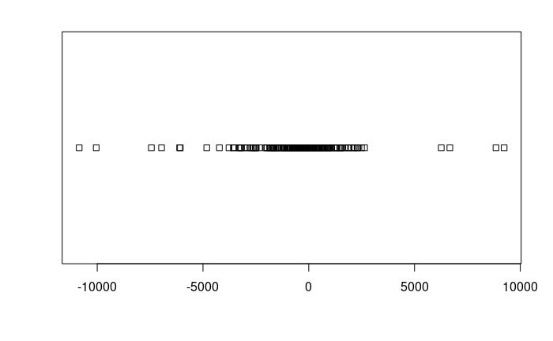

```r
stripchart(differences$diff)
```

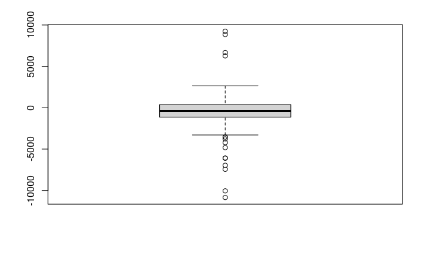

```r
boxplot(differences$diff)
```

We see quite a big difference in the PLT. Might be interesting to look at the outliers. As we can see the majority of these outliers are all from the same subjects.

```r
outliers <- boxplot.stats(differences$diff)$out
out_ind <- which(differences$diff %in% c(outliers))
differences[out_ind,]
```

|  | subject | diff |
| --- | --- | --- |
| 37 | dallasnews-com | -10048 |
| 39 | dallasnews-com | 9237 |
| 69 | freeagent-com | -3564 |
| 94 | jezebel-com | -6073 |
| 105 | manchestereveningnews-co | -4823 |
| 116 | nationalreview-com | -6106 |
| 117 | nationalreview-com | 8850 |
| 118 | nationalreview-com | -6959 |
| 120 | nationalreview-com | -3772 |
| 123 | ncaa-com | -10853 |

[output cut: 5 more lines]

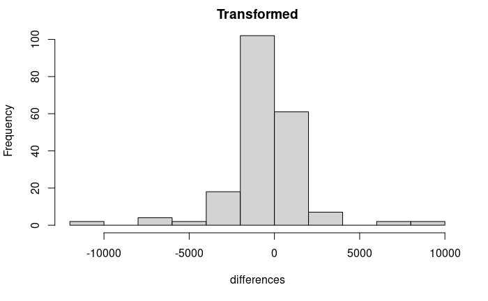

```
[1] "Transformed:  none"

    Shapiro-Wilk normality test

data:  differences
W = 0.83455, p-value = 8.108e-14

[1] "Skewness after transformation -0.293540529142458"
```

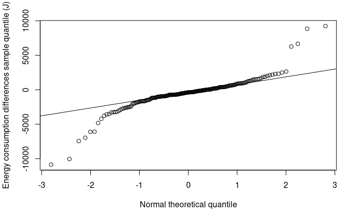

```r
transform_and_test(removed$plt, intact$plt)
```

Since the differences are not normally distributed we apply several transformations to see if we can approach a normal distribution.

```
[1] "Changed.."
```

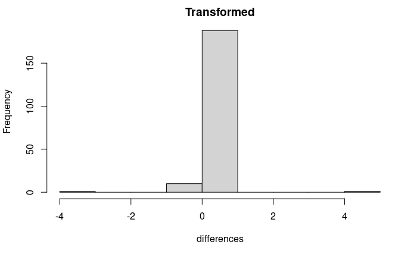

```
[1] "Transformed:  log"

    Shapiro-Wilk normality test

data:  differences
W = 0.19368, p-value < 2.2e-16

[1] "Skewness after transformation 0.424054150377743"
```

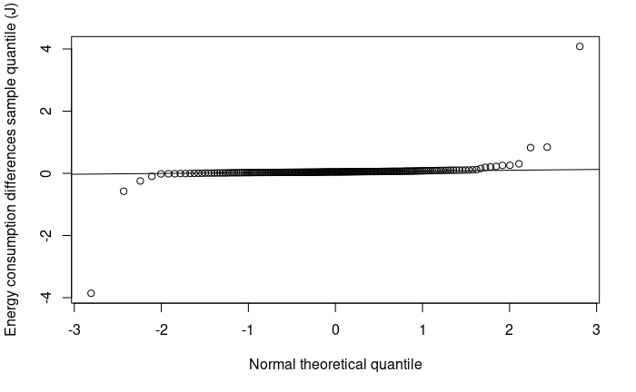

```r
transform_and_test(removed$plt, intact$plt, "log", reverse=TRUE)
```

```
[1] "Changed.."
```

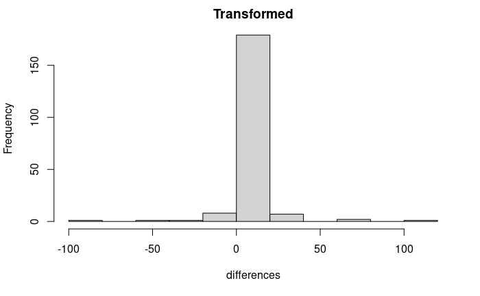

```
[1] "Transformed:  sqrt"

    Shapiro-Wilk normality test

data:  differences
W = 0.56162, p-value < 2.2e-16

[1] "Skewness after transformation 0.967657806189625"
```

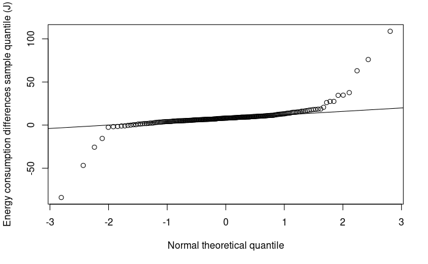

```r
transform_and_test(removed$plt, intact$plt, "sqrt", reverse=TRUE)
```

```
[1] "Changed.."
```

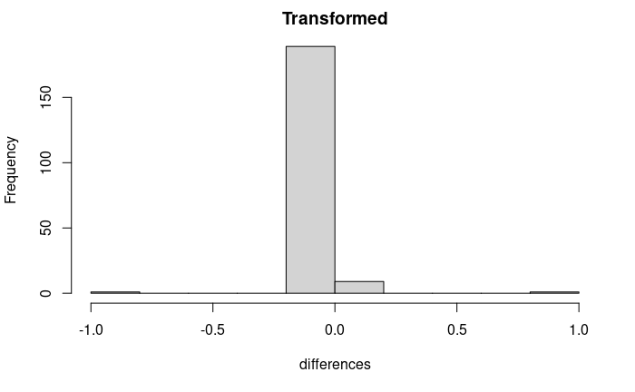

```
[1] "Transformed:  recip"

    Shapiro-Wilk normality test

data:  differences
W = 0.087771, p-value < 2.2e-16

[1] "Skewness after transformation -0.000550928561808198"
```

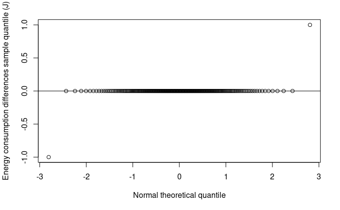

```r
transform_and_test(removed$plt, intact$plt, "recip", reverse=TRUE)
```

We can see that for all three transformations the data is not normally distributed.

# Hypothesis Testing

Since the data is not normally distributed we will use the Wilcoxon signed rank test:

```r
wilcox.test(removed$plt, intact$plt, paired=TRUE)
```

```
    Wilcoxon signed rank test with continuity correction

data:  removed$plt and intact$plt
V = 6467, p-value = 1.235e-05
alternative hypothesis: true location shift is not equal to 0
```

As we can see this tests gives a p-value of 1.235-05 which is below our 0.05 treshold and thus we reject the null hypothesis. So we are able to claim that there is a significant difference in PLT between MWP that use resource preloading or not.

# Effect Size Estimation

```r
cliffs_delta_plt <- cliff.delta(removed$plt, intact$plt)
print(cliffs_delta_plt)
```

```
Cliff's Delta

delta estimate: -0.0824 (negligible)
95 percent confidence interval:
      lower       upper
-0.19416929  0.03148128
```

As expected the value of the Cliff’s delta measure is negligible.